# Packages in R

Mr. Sachin B.

### What are R Packages?

The package is an suitable way to organize the work and share it with others.  
R packages are collections of functions and data sets developed by the community.  
These are stored under a directory called “library”" within the R environment.  
By default, R installs a group of packages during installation.  
Once we start the R console, only the default packages are available by default.  
Other packages that are already installed need to be loaded explicitly to be utilized by the R program that is getting to use them.

#### Library locations of R packages

```r
.libPaths()
```

```
## [1] "C:/Users/admin/Documents/R/win-library/4.0"
## [2] "C:/Program Files/R/R-4.0.2/library"
```

#### List of all the packages installed

```r
library()
```

#### All the packages currently loaded in the R environment

```r
search()
```

#### Package **Description**, **Help** and **Vignettes**

```r
# Access the Package Description from Documentation file of the Package inside R

 packageDescription("ggplot2")


# Access the Package Help file from Package inside R.

 help(package = "ggplot2")


# See Functions inside Packages

 ls("package:stats")


# Help for Individual Functions inside Packages

 help("xtabs")
 help(xtabs, package = "stats")


#vignettes are documents where the authors show some functionalities of their package in a more detailed way.

 browseVignettes()
 browseVignettes(package="ggplot2")
 vignette()
 vignette(package = "ggplot2")
 vignette("ggplot2-specs")
```

### What are Repositories?

A repository is a place where packages are located so you can install them from it.  
Three of the most popular repositories for R packages are:

**CRAN:** **The Comprehensive R Archive Network** is the official repository, it is a network of ftp and web servers maintained by the R community around the world.

**Bioconductor:** this is a topic specific repository, intended for open source software for bioinformatics.

**Github:** although this is not R specific, Github is probably the most popular repository for open source projects. Its popularity comes from the unlimited space for open source, the integration with git, a version control software, and its ease to share and collaborate with others.

### How to Install packages

#### 1. Installing Packages From CRAN

```r
# Install Single Package from CRAN

 install.packages("MASS")


# Install Multiple Packages at Same time from CRAN

 install.packages(c("plyr", "dplyr"))


# Install Package from Specific CRAN Mirror

 install.packages('RMySQL', repos='http://cran.us.r-project.org')
```

#### 2. Installing Packages From Local Directory

```r
 install.packages("C:/Users/admin/Downloads/tidyr_1.1.2.zip", repos=NULL, type="source")
```

#### 3. Installing Bioconductor Packages

```r
 if (!requireNamespace("BiocManager", quietly = TRUE))
     install.packages("BiocManager")
 BiocManager::install(version = "3.12")
```

#### 4. Installing Packages Via devtools

Need to Install Rtools: https://cran.rstudio.com/bin/windows/Rtools/

```r
 install.packages("devtools")
```

After devtools is installed, you will be able to use the utility functions to install another packages. The options are:

- install_cran() from CRAN
- install_git() from a git repository
- install_github() from GitHub
- install_local() from a local file
- install_svn() from a SVN repository
- install_url() from a URL
- install_bioc() from Bioconductor
- install_bitbucket() from Bitbucket
- install_version() from a specific version of a CRAN package.

```r
library("devtools")

# install_cran() from CRAN

  install_cran("ggplot2")
  install_cran(c("httpuv", "shiny"))


# install_git() from a git repository

  install_git("git://github.com/hadley/stringr.git")


# install_github() from GitHub

  install_github("klutometis/roxygen")


# install_local() from a local file

  install_local("C:/Users/admin/Downloads/tidyr_1.1.2.zip")


# install_svn() from a SVN repository

  install_svn("https://github.com/hadley/httr")


# install_url() from a URL

  install_url("https://github.com/hadley/stringr/archive/master.zip")


# install_bioc() from Bioconductor

  install_bioc("SummarizedExperiment")


# install_bitbucket() from Bitbucket

  install_bitbucket("sulab/mygene.r@default")
```

#### 5. Installing Packages From GitHub

Need to Install Rtools: https://cran.rstudio.com/bin/windows/Rtools/

```r
 install.packages("devtools")
 library(devtools)

 install_github("klutometis/roxygen")
 install_github("hadley/rvest")
```

### How To Update, Remove And Check Installed Packages

```r
#To check what packages are installed on your computer

 installed.packages()


#Uninstalling a package

 remove.packages("MASS")


#Check what packages need an update

 old.packages()


#You can update all packages

 update.packages()
```

### User Interfaces For Installing Packages

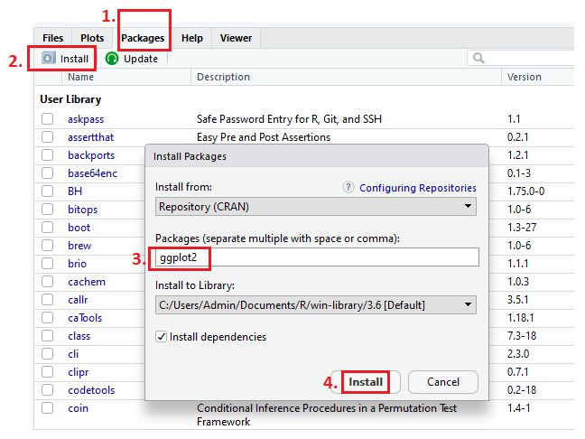

### Load and Unload Packages

```r
# Load Packages

  library(ggplot2)
  qplot(1:10,seq(1,100,by=10))


# Unload Packages

  detach(ggplot2)
```

### Acces Package functions without loading Package

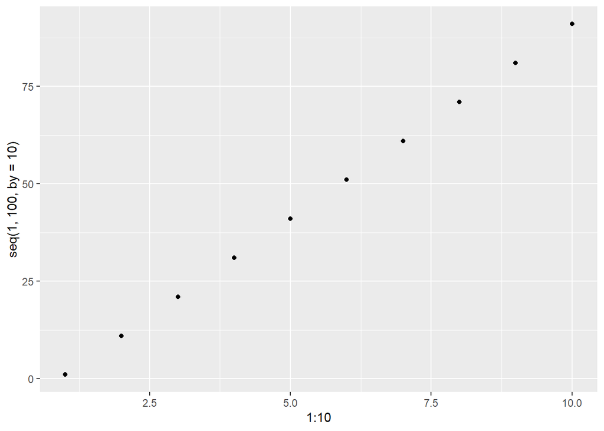

```r
ggplot2::qplot(1:10,seq(1,100,by=10))
```